# NBA Best Shooting Team

### Project Outline

1. Gathering the data
2. Tidying the data
3. Exploratory Data Analysis
4. Hypothesis Testing
5. Conclusion

### Part 1. Gathering The Data

First we will need the data so we will download the dataset from https://www.kaggle.com/dansbecker/nba-shot-logs/data. The dataset is a CSV or comma separated file which can be read using [read_csv()](https://readr.tidyverse.org/reference/read_delim.html). When read_csv() reads in the file it will create a [dataframe](http://www.r-tutor.com/r-introduction/data-frame) which is a table of data.

```
## # A tibble: 10 x 21
##    GAME_ID MATCHUP LOCATION W     FINAL_MARGIN SHOT_NUMBER PERIOD GAME_CLOCK
##      <dbl> <chr>   <chr>    <chr>        <dbl>       <dbl>  <dbl> <time>
##  1  2.14e7 MAR 04… A        W               24           1      1 01:09
##  2  2.14e7 MAR 04… A        W               24           2      1 00:14
##  3  2.14e7 MAR 04… A        W               24           3      1 00:00
##  4  2.14e7 MAR 04… A        W               24           4      2 11:47
##  5  2.14e7 MAR 04… A        W               24           5      2 10:34
##  6  2.14e7 MAR 04… A        W               24           6      2 08:15
##  7  2.14e7 MAR 04… A        W               24           7      4 10:15
##  8  2.14e7 MAR 04… A        W               24           8      4 08:00
##  9  2.14e7 MAR 04… A        W               24           9      4 05:14
## 10  2.14e7 MAR 03… H        W                1           1      2 11:32
## # … with 13 more variables: SHOT_CLOCK <dbl>, DRIBBLES <dbl>, TOUCH_TIME <dbl>,
## #   SHOT_DIST <dbl>, PTS_TYPE <dbl>, SHOT_RESULT <chr>, CLOSEST_DEFENDER <chr>,
## #   CLOSEST_DEFENDER_PLAYER_ID <dbl>, CLOSE_DEF_DIST <dbl>, FGM <dbl>,
## #   PTS <dbl>, player_name <chr>, player_id <dbl>
```

### 2. Tidying The Data

When working with tidy data we assume that:  
1. Each attribute or variable forms a column.  
2. Each entity or observation forms a row.  
3. Each type of entity or observational unit forms a table

The data might not always be easy to read or clean. Some problems with messy data include column headers being values, multiple variables being stored in one column, variables being stored in both rows and columns, multiple types of observational units being stored in the same table, and single observational units being stored in multiple tables.

Fortunately, the dataset we are working with is pretty tidy already. All the variables are in their own columns, the observations are in rows, and there is not much missing data. To tidy the data a little we will remove some of the columns that we will not need when doing analysis. We will also rearrange the columns to make it easier to read.

```r
remove_cols <- c("GAME_ID", "LOCATION")
season_stats_df <- season_stats_df[ , !(names(season_stats_df) %in% remove_cols)]

season_stats_df <- season_stats_df[, c("player_name", "player_id", "MATCHUP", "SHOT_NUMBER", "PERIOD", "GAME_CLOCK", "SHOT_CLOCK", "DRIBBLES", "TOUCH_TIME", "SHOT_DIST", "PTS_TYPE", "SHOT_RESULT", "FGM", "PTS", "CLOSEST_DEFENDER", "CLOSEST_DEFENDER_PLAYER_ID", "CLOSE_DEF_DIST", "W", "FINAL_MARGIN")]
head(season_stats_df, n = 10)
```

```
## # A tibble: 10 x 19
##    player_name player_id MATCHUP SHOT_NUMBER PERIOD GAME_CLOCK SHOT_CLOCK
##    <chr>           <dbl> <chr>         <dbl>  <dbl> <time>          <dbl>
##  1 brian robe…    203148 MAR 04…           1      1 01:09            10.8
##  2 brian robe…    203148 MAR 04…           2      1 00:14             3.4
##  3 brian robe…    203148 MAR 04…           3      1 00:00            NA
##  4 brian robe…    203148 MAR 04…           4      2 11:47            10.3
##  5 brian robe…    203148 MAR 04…           5      2 10:34            10.9
##  6 brian robe…    203148 MAR 04…           6      2 08:15             9.1
##  7 brian robe…    203148 MAR 04…           7      4 10:15            14.5
##  8 brian robe…    203148 MAR 04…           8      4 08:00             3.4
##  9 brian robe…    203148 MAR 04…           9      4 05:14            12.4
## 10 brian robe…    203148 MAR 03…           1      2 11:32            17.4
## # … with 12 more variables: DRIBBLES <dbl>, TOUCH_TIME <dbl>, SHOT_DIST <dbl>,
## #   PTS_TYPE <dbl>, SHOT_RESULT <chr>, FGM <dbl>, PTS <dbl>,
## #   CLOSEST_DEFENDER <chr>, CLOSEST_DEFENDER_PLAYER_ID <dbl>,
## #   CLOSE_DEF_DIST <dbl>, W <chr>, FINAL_MARGIN <dbl>
```

```r
season_stats_df$SHOT_CLOCK[is.na(season_stats_df$SHOT_CLOCK)] <- 0.0
season_stats_df$GAME_CLOCK <- season_stats_df$GAME_CLOCK / 60
season_stats_df$MATCHUP <- substring(season_stats_df$MATCHUP, 15, 18)
names(season_stats_df)[names(season_stats_df) == "MATCHUP"] <- "TEAM"
head(season_stats_df, n = 10)
```

```
## # A tibble: 10 x 19
##    player_name player_id TEAM  SHOT_NUMBER PERIOD GAME_CLOCK SHOT_CLOCK DRIBBLES
##    <chr>           <dbl> <chr>       <dbl>  <dbl> <drtn>          <dbl>    <dbl>
##  1 brian robe…    203148 " CH…           1      1  69 secs         10.8        2
##  2 brian robe…    203148 " CH…           2      1  14 secs          3.4        0
##  3 brian robe…    203148 " CH…           3      1   0 secs          0          3
##  4 brian robe…    203148 " CH…           4      2 707 secs         10.3        2
##  5 brian robe…    203148 " CH…           5      2 634 secs         10.9        2
##  6 brian robe…    203148 " CH…           6      2 495 secs          9.1        2
##  7 brian robe…    203148 " CH…           7      4 615 secs         14.5       11
##  8 brian robe…    203148 " CH…           8      4 480 secs          3.4        3
##  9 brian robe…    203148 " CH…           9      4 314 secs         12.4        0
## 10 brian robe…    203148 " CH…           1      2 692 secs         17.4        0
## # … with 11 more variables: TOUCH_TIME <dbl>, SHOT_DIST <dbl>, PTS_TYPE <dbl>,
## #   SHOT_RESULT <chr>, FGM <dbl>, PTS <dbl>, CLOSEST_DEFENDER <chr>,
## #   CLOSEST_DEFENDER_PLAYER_ID <dbl>, CLOSE_DEF_DIST <dbl>, W <chr>,
## #   FINAL_MARGIN <dbl>
```

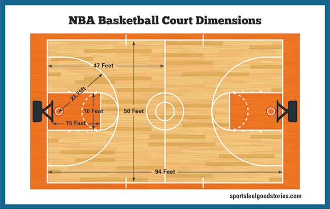

Here I include an image of a NBA basketball court and its dimensions to help familiarize you with the different dimensions. The paint area is the area shaded in orange on both sides of the court and is about 15 feet by 16 feet. The three point line is the line around the basket that is 23.75 feet away. Any shot behind this line is called a three pointer because of the fact that the shot is worth three points. Anyshot made inside the three point line is worth two points.

Finally we will create a new column to determine the type of shot that was taken based on the shot distance and points type. If the points are 3 then the shot is a three pointer. If the shot distance is 2 feet away from the basket or less it will be considered a dunk or layup, 10 feet away or less it will be considered a shot in the paint, more than 10 feet away and less than 17 or equal to will be a mid range shot, and any shot greater than 17 feet and 2 points type will be a long range two shot.

### 3. Exploratory Data Analysis

Now that the data is tidy and easily readable and understandable we will do some analysis. This will help us to better understand our data and help us make decisions about statistical and machine learning methods. We will use both visualizations and statistical methods to help us learn about general trends in the data.

#### 3.1 Some NBA Statistics

First we will take a look at some statistics regarding teams with the highest field goal percentage. We first create a new data frame called team_fgpct_df which includes the number of made, missed, and total shots by each team. To find the total number of shots made and missed we will use [group_by()](https://dplyr.tidyverse.org/reference/group_by.html) which splits data into groups by each team and [summarise()](https://www.rdocumentation.org/packages/dplyr/versions/0.7.8/topics/summarise) which collapses each group into a single-row summary so we have data for teams rather than individual players. Once we have the made and missed shots for each team we can add them together to get the total. And finally we divide the shots made by the total to get the field goal percentage for each team. We display the output from highest to lowest in terms of field goal percentage.

```r
team_fgpct_df <- data.frame()

team_fgpct_df <- season_stats_df %>%
  group_by(TEAM) %>%
  summarise(sum(SHOT_RESULT == "made"), sum(SHOT_RESULT == "missed"))
names(team_fgpct_df)[names(team_fgpct_df) == "sum(SHOT_RESULT == \"made\")"] <- "Made"
names(team_fgpct_df)[names(team_fgpct_df) == "sum(SHOT_RESULT == \"missed\")"] <- "Missed"
team_fgpct_df$Total <- team_fgpct_df$Made + team_fgpct_df$Missed
team_fgpct_df$FG_PCT <- team_fgpct_df$Made / team_fgpct_df$Total

head(team_fgpct_df[order(-team_fgpct_df$FG_PCT),])
```

```
## # A tibble: 6 x 5
##   TEAM    Made Missed Total FG_PCT
##   <chr>  <int>  <int> <int>  <dbl>
## 1 " GSW"  2182   2371  4553  0.479
## 2 " LAC"  2303   2538  4841  0.476
## 3 " WAS"  2253   2540  4793  0.470
## 4 " NOP"  1897   2148  4045  0.469
## 5 " ATL"  2128   2416  4544  0.468
## 6 " CLE"  1830   2094  3924  0.466
```

```r
team_final_margin_df <- data.frame()

team_final_margin_df <- season_stats_df %>%
  select(player_name, TEAM, FINAL_MARGIN) %>%
  distinct()

team_final_margin_df <- team_final_margin_df %>%
  group_by(player_name, TEAM) %>%
  summarise(sum(FINAL_MARGIN))

names(team_final_margin_df)[names(team_final_margin_df) == "sum(FINAL_MARGIN)"] <- "FINAL_MARGIN"

team_final_margin_df <- team_final_margin_df %>%
  group_by(TEAM) %>%
  summarise(sum(FINAL_MARGIN) / 82)

names(team_final_margin_df)[names(team_final_margin_df) == "sum(FINAL_MARGIN)/82"] <- "FINAL_MARGIN"
head(team_final_margin_df[order(-team_final_margin_df$FINAL_MARGIN),])
```

```
## # A tibble: 6 x 2
##   TEAM   FINAL_MARGIN
##   <chr>         <dbl>
## 1 " GSW"         37.0
## 2 " LAC"         30.9
## 3 " CLE"         20.9
## 4 " ATL"         19.0
## 5 " DAL"         16.1
## 6 " SAS"         13.5
```

Here we can see that pretty much the teams with the highest field goal percentages have the largest average margin of victory which makes sense because the more shots a team makes, usually translates to more points and larger margins of victory.

#### 3.2 Finding Trends in Our Data

Now we will see if we can find any interesting trends in our data by doing data visualization and statistical analysis. If you aren’t familiar with a basketball court and the shot locations I have included an image here that shows the different spots on the court.

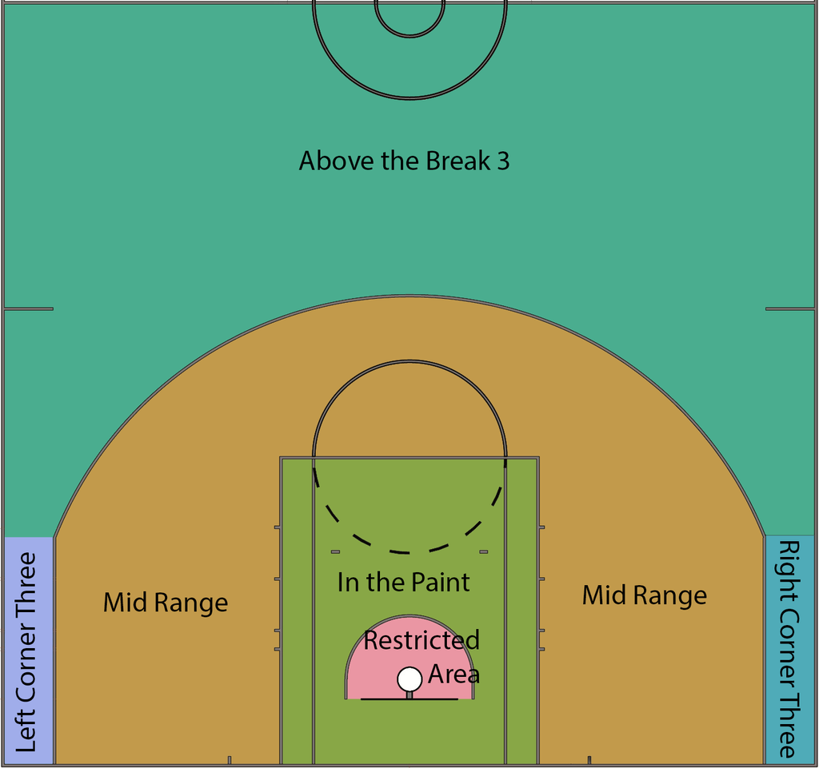

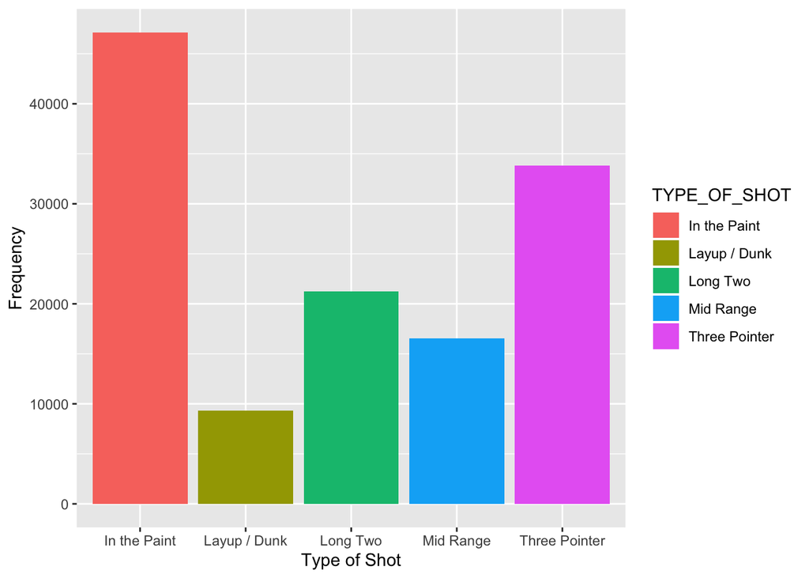

```r
season_stats_df %>%
  ggplot(aes(TYPE_OF_SHOT, fill = TYPE_OF_SHOT)) + geom_bar() + xlab("Type of Shot") + ylab("Frequency")
```

From our graph we can see that shots in the paint and three pointers are the most frequently taken shots. This makes sense because shots in the paint are close to the basket and three pointers are worth the most points.

Now we can look at the percentages of each of these shots to see if the players shot selections make sense.

```r
shot_type_pct <- data_frame()
shot_type_pct <- season_stats_df %>%
  select(TYPE_OF_SHOT, FGM)

shot_type_pct <- shot_type_pct %>%
  group_by(TYPE_OF_SHOT, FGM) %>%
  tally() %>%
  spread(FGM, n)

shot_type_pct$Total <- shot_type_pct$'0' + shot_type_pct$'1'
shot_type_pct$FG_PCT <- shot_type_pct$'1' / shot_type_pct$Total

head(shot_type_pct[order(-shot_type_pct$FG_PCT),])
```

```
## # A tibble: 5 x 5
## # Groups:   TYPE_OF_SHOT [5]
##   TYPE_OF_SHOT    `0`   `1` Total FG_PCT
##   <chr>         <int> <int> <int>  <dbl>
## 1 Layup / Dunk   3325  5994  9319  0.643
## 2 In the Paint  22346 24794 47140  0.526
## 3 Mid Range      9741  6816 16557  0.412
## 4 Long Two      12827  8391 21218  0.395
## 5 Three Pointer 21925 11910 33835  0.352
```

From our results we can see that layup/dunk has the highest field goal percentage while three pointer has the lowest field goal percentage. And this makes sense because the closer you are to the basket the easier the shot is going to be to make. Therefore, the percentages decrease with distance away from the basket.

Now we will take a look at the average amount of points a player is expected to score based on the distance away from the basket. To do this we will simply take the FG_PCT and multiply it by the number of points allocated for that shot, which is 2 points for all shots except three pointers which is 3 points.

```r
total_shots <- sum(shot_type_pct$Total)
shot_type_pct$PCT_OF_TOTAL <- shot_type_pct$Total / total_shots
shot_type_pct$POINTS_EXP <- shot_type_pct$FG_PCT * 2.0
shot_type_pct$POINTS_EXP[5] <- shot_type_pct$FG_PCT * 3.0
shot_type_pct
```

```
## # A tibble: 5 x 7
## # Groups:   TYPE_OF_SHOT [5]
##   TYPE_OF_SHOT    `0`   `1` Total FG_PCT PCT_OF_TOTAL POINTS_EXP
##   <chr>         <int> <int> <int>  <dbl>        <dbl>      <dbl>
## 1 In the Paint  22346 24794 47140  0.526       0.368       1.05
## 2 Layup / Dunk   3325  5994  9319  0.643       0.0728      1.29
## 3 Long Two      12827  8391 21218  0.395       0.166       0.791
## 4 Mid Range      9741  6816 16557  0.412       0.129       0.823
## 5 Three Pointer 21925 11910 33835  0.352       0.264       1.58
```

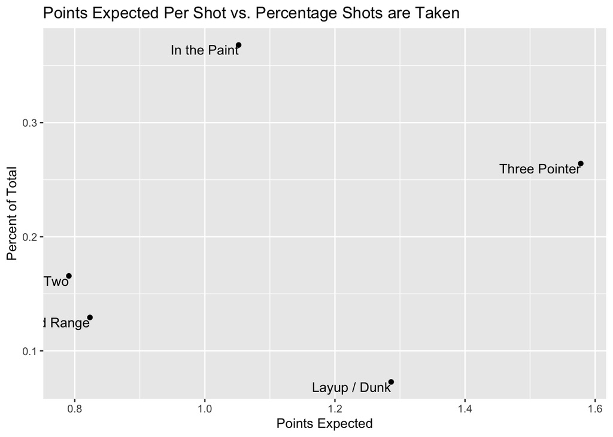

```r
shot_type_pct %>%
  ggplot(aes(x = POINTS_EXP, y = PCT_OF_TOTAL, label = TYPE_OF_SHOT)) + geom_point() + labs(title = "Points Expected Per Shot vs. Percentage Shots are Taken", x = "Points Expected", y = "Percent of Total") + geom_text(aes(label=TYPE_OF_SHOT),hjust=1, vjust=1)
```

Now let’s take a look at an individual team’s points per shot and percentage of shots taken. We will look at the Golden State Warriors, probably the best overall team during the 2014-2015 NBA season.

```r
GSW_shots <- data_frame()

GSW_shots <- season_stats_df %>%
  select(TEAM, TYPE_OF_SHOT, FGM)

GSW_shots <- GSW_shots %>%
  group_by(TEAM, TYPE_OF_SHOT, FGM) %>%
  tally() %>%
  spread(FGM, n)

GSW_shots$Total <- GSW_shots$'0' + GSW_shots$'1'
GSW_shots$FG_PCT <- GSW_shots$'1' / GSW_shots$Total

GSW <- GSW_shots %>%
  filter(Total == 1503 | Total == 340 | Total == 634 | (Total == 577 & FG_PCT > 0.39) | Total == 1499)

GSW
```

```
## # A tibble: 5 x 6
## # Groups:   TEAM, TYPE_OF_SHOT [5]
##   TEAM   TYPE_OF_SHOT    `0`   `1` Total FG_PCT
##   <chr>  <chr>         <int> <int> <int>  <dbl>
## 1 " GSW" In the Paint    660   843  1503  0.561
## 2 " GSW" Layup / Dunk    119   221   340  0.65
## 3 " GSW" Long Two        376   258   634  0.407
## 4 " GSW" Mid Range       317   260   577  0.451
## 5 " GSW" Three Pointer   899   600  1499  0.400
```

Here we can see that the Golden State Warriors take a majority of their shots either in the paint or from three. Next we will see this visually like we did for the entire NBA.

```r
total_shots <- sum(GSW$Total)
GSW$PCT_OF_TOTAL <- GSW$Total / total_shots
GSW$POINTS_EXP <- GSW$FG_PCT * 2.0
GSW$POINTS_EXP[5] <- GSW$FG_PCT * 3.0
```

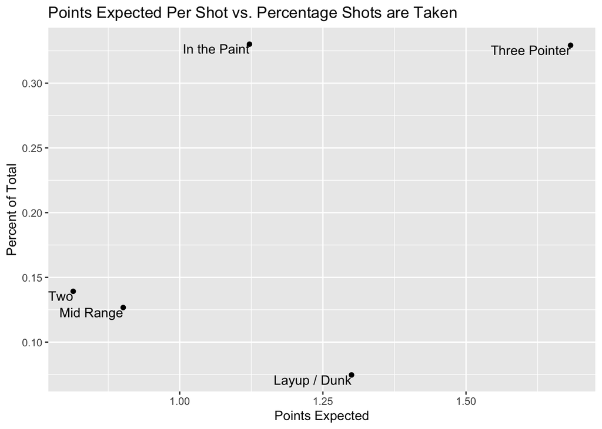

```r
GSW %>%
  ggplot(aes(x = POINTS_EXP, y = PCT_OF_TOTAL, label = TYPE_OF_SHOT)) + geom_point() + labs(title = "Points Expected Per Shot vs. Percentage Shots are Taken", x = "Points Expected", y = "Percent of Total") + geom_text(aes(label=TYPE_OF_SHOT),hjust=1, vjust=1)
```

#### 3.3 Visualizing Shooting Data

In this section we will take a look at some more advanced data visualization. A question we may want to answer is does the shot distance depend at all on the time left in a game.

To do this we will use a [hexbin()](https://www.rdocumentation.org/packages/hexbin/versions/1.29.0/topics/hexbin) to create a heatmap showing the time left on the clock versus the shot distance for the Golden State Warriors.

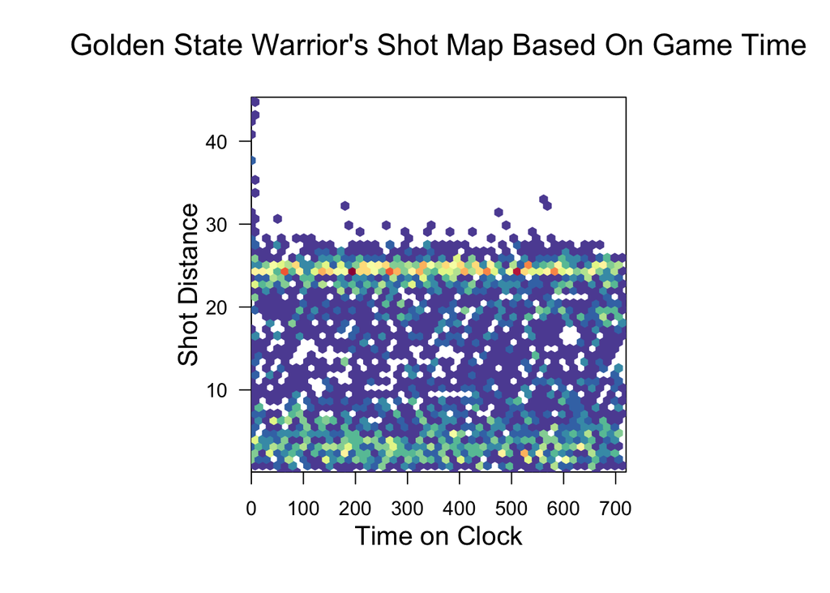

```r
stats <- season_stats_df %>%
  filter(str_detect(TEAM, "GSW")) %>%
  select(SHOT_DIST, GAME_CLOCK)

stats$GAME_CLOCK <- as.numeric(stats$GAME_CLOCK)

bin<-hexbin(stats$GAME_CLOCK, stats$SHOT_DIST, xbins=50)
my_colors=colorRampPalette(rev(brewer.pal(11,'Spectral')))
plot(bin, xlab="Time on Clock", ylab="Shot Distance", main="Golden State Warrior's Shot Map Based On Game Time" , colramp=my_colors , legend=F)
```

From the graph we can see that lighter blues, reds, and yellows show the higher density regions and the darker colors show the less dense regions. It appears that over time shot distances stay relatively the same being mostly populated in the 25 foot range and less than 5 feet range. These two distances correspond to three pointers and shots in the paint respectively.

Now we will see how these results compare to all the teams in the NBA.

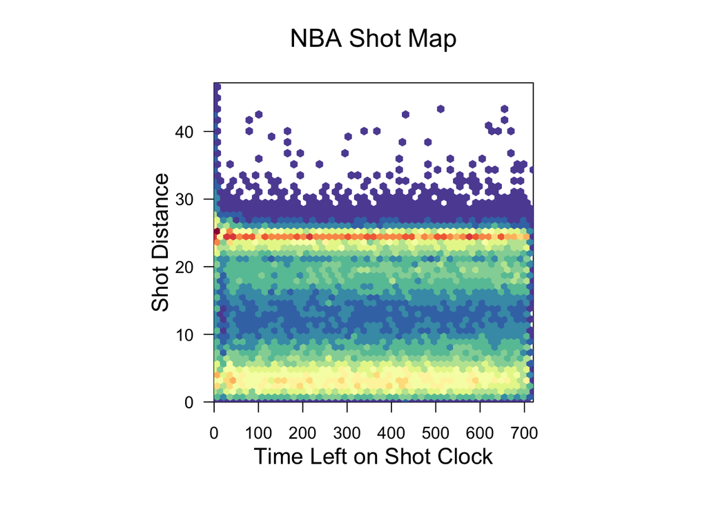

```r
stats <- season_stats_df %>%
  select(GAME_CLOCK, SHOT_DIST)

stats$GAME_CLOCK <- as.numeric(stats$GAME_CLOCK)

bin<-hexbin(stats$GAME_CLOCK, stats$SHOT_DIST, xbins=50)
my_colors=colorRampPalette(rev(brewer.pal(11,'Spectral')))
plot(bin, xlab="Time Left on Shot Clock", ylab="Shot Distance", main="NBA Shot Map" , colramp=my_colors , legend=F)
```

We can see that the results are pretty much the same. An interesting trend in the graph is that with just about 0 seconds left on the clock there are a lot more shots at all distances. This is probably because at the end of a game players are shooting from any distance, especially when games are close to try and score at the last second.

### 4. Hypothesis Testing

Now we will use our statistics to test if the NBA shooting percentage in the last minutes of the game is different from the entire game. More specifically, we will use hypothesis testing. To learn more about hypothesis testing you can check [here](https://www.statisticshowto.com/probability-and-statistics/hypothesis-testing/). The hypothesis test that we will be using is a t-test which tests if two means are equal. To learn more about t-tests you can check [here](https://www.investopedia.com/terms/t/t-test.asp).

First we will create a new data frame that includes data only in the last mintue of games for all teams including the field goal or shooting percentage.

```r
team_fgpct_last_min <- data.frame()

team_fgpct_last_min <- season_stats_df %>%
  filter(GAME_CLOCK <= 60) %>%
  group_by(TEAM) %>%
  summarise(sum(SHOT_RESULT == "made"), sum(SHOT_RESULT == "missed"))
names(team_fgpct_last_min)[names(team_fgpct_last_min) == "sum(SHOT_RESULT == \"made\")"] <- "Made"
names(team_fgpct_last_min)[names(team_fgpct_last_min) == "sum(SHOT_RESULT == \"missed\")"] <- "Missed"
team_fgpct_last_min$Total <- team_fgpct_last_min$Made + team_fgpct_last_min$Missed
team_fgpct_last_min$FG_PCT <- team_fgpct_last_min$Made / team_fgpct_last_min$Total
team_fgpct_last_min
```

```
## # A tibble: 30 x 5
##    TEAM    Made Missed Total FG_PCT
##    <chr>  <int>  <int> <int>  <dbl>
##  1 " ATL"   189    236   425  0.445
##  2 " BKN"   172    259   431  0.399
##  3 " BOS"   171    282   453  0.377
##  4 " CHA"   186    266   452  0.412
##  5 " CHI"   184    291   475  0.387
##  6 " CLE"   157    206   363  0.433
##  7 " DAL"   181    258   439  0.412
##  8 " DEN"   162    281   443  0.366
##  9 " DET"   165    257   422  0.391
## 10 " GSW"   182    220   402  0.453
## # … with 20 more rows
```

Now that we have this new data frame we can perform our t-test. Our null hypothesis will be that the field goal percentages are equal. Our alternative hypothesis will be that the field goal percentages are different.

```r
t.test(team_fgpct_df$FG_PCT, team_fgpct_last_min$FG_PCT)
```

```
##
##  Welch Two Sample t-test
##
## data:  team_fgpct_df$FG_PCT and team_fgpct_last_min$FG_PCT
## t = 8.5776, df = 46.122, p-value = 4.135e-11
## alternative hypothesis: true difference in means is not equal to 0
## 95 percent confidence interval:
##  0.03694917 0.05960611
## sample estimates:
## mean of x mean of y
## 0.4517292 0.4034516
```

### 5. Conclusion

The dataset we worked with contains a lot of data and there is a lot more interesting things we can do with it. The possibilities are endless and I encourage everyone to complete their own experiements with this data.